# Solution

Alexander Gerber & Martin Arnold

11/11/2019

1. Experiment with geom_point() using the mtcars data set. Try out different aesthetics with different variables. What do you note?

   Plot weight against horsepower:

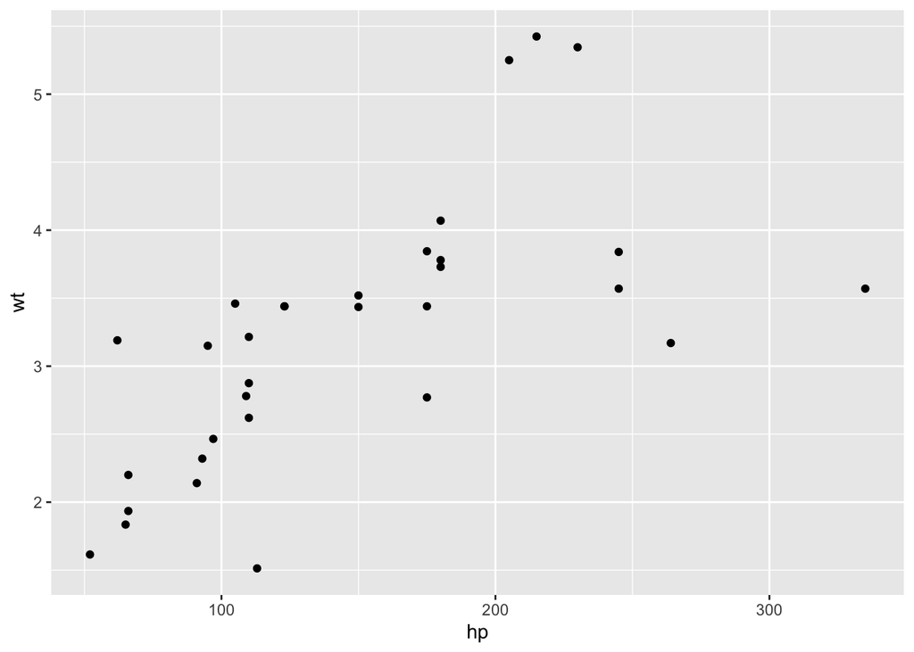

   ```r
   library(ggplot2)
   ggplot(mtcars, aes(x = hp, y = wt)) +
     geom_point()
   ```

   Plot weight against color the points according to gear:

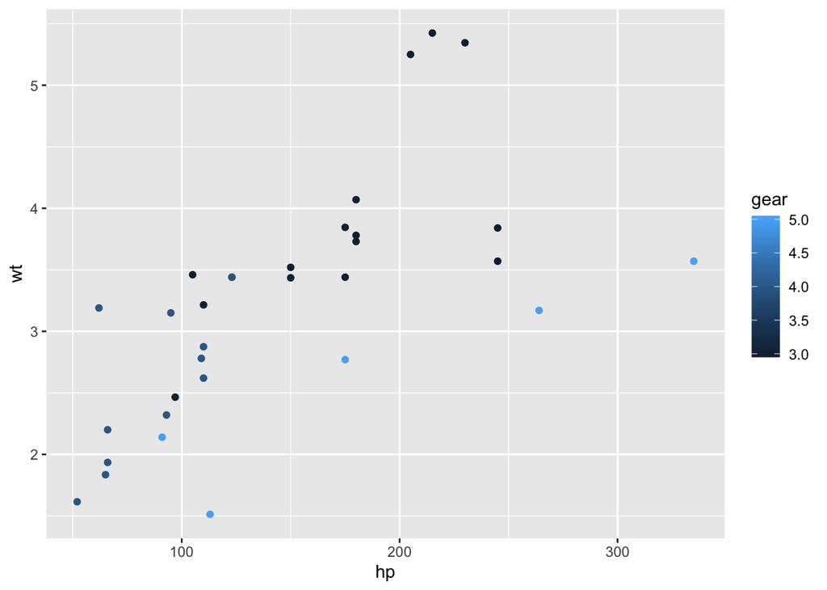

   ```r
   ggplot(mtcars, aes(x = hp, y = wt, color = gear)) +
     geom_point()
   ```

   Plot weight against color the points according to gear as a categorical variable:

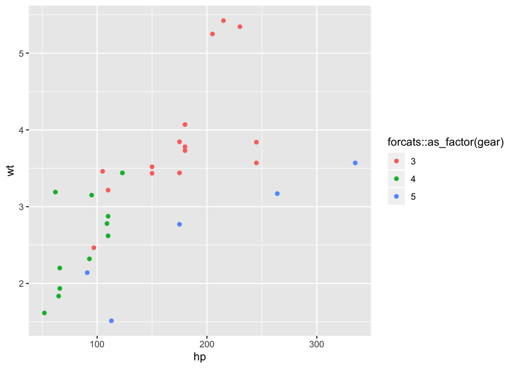

   ```r
   ggplot(mtcars, aes(x = hp, y = wt, color = forcats::as_factor(gear))) +
     geom_point()
   ```

   Use gear on the y axis.

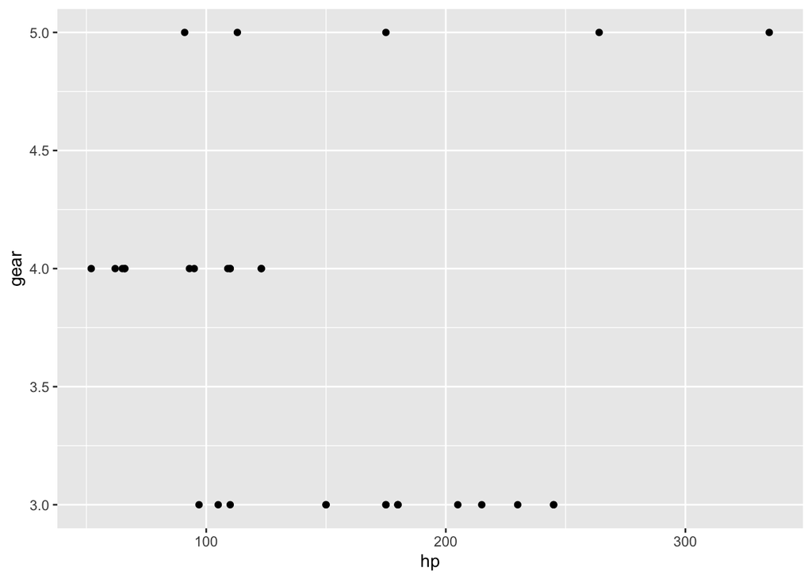

   ```r
   ggplot(mtcars, aes(x = hp, y = gear)) +
     geom_point()
   ```

2. Use the mtcars data set and plot mpg vs. hp. Add a smoothing line to the plot.

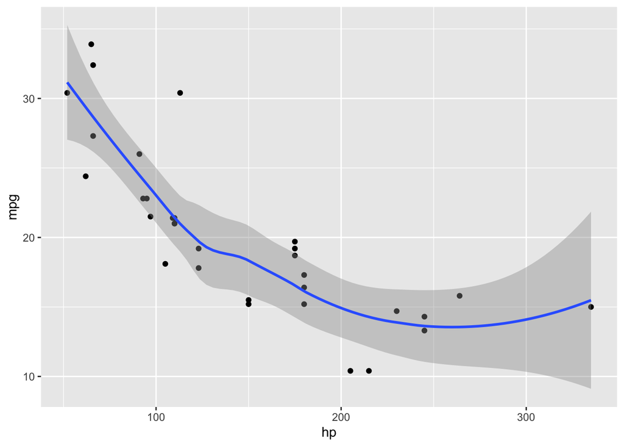

   ```r
   ggplot(mtcars, aes(hp, mpg)) +
     geom_point() +
     geom_smooth()
   ```

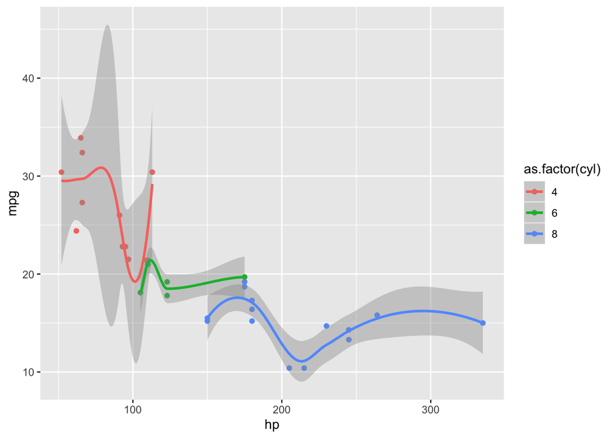

   ```r
   ggplot(mtcars, aes(hp, mpg, color = as.factor(cyl))) +
     geom_point() +
     geom_smooth()
   ```

4. Find out how to remove the confidence interval.

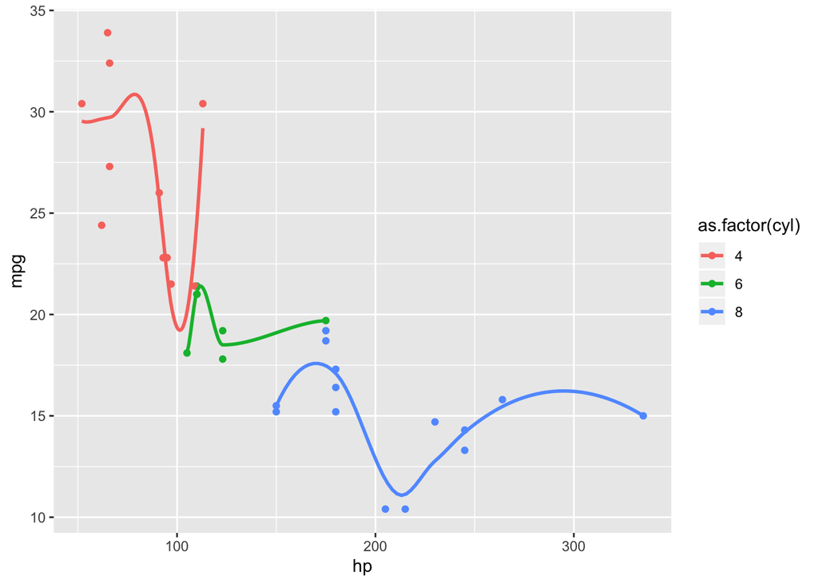

   ```r
   ggplot(mtcars, aes(hp, mpg, color = as.factor(cyl))) +
     geom_point() +
     geom_smooth(se = FALSE)
   ```

5. Use a simple linear regression model and a quadratic regression model for smoothing.

   Simple linear regression model

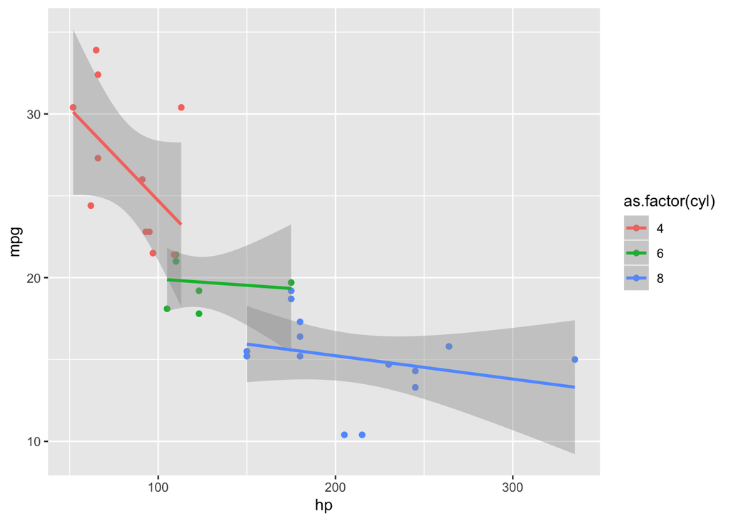

   ```r
   ggplot(mtcars, aes(hp, mpg, color = as.factor(cyl))) +
     geom_point() +
     geom_smooth(method = lm)
   ```

   Quadratic regression model

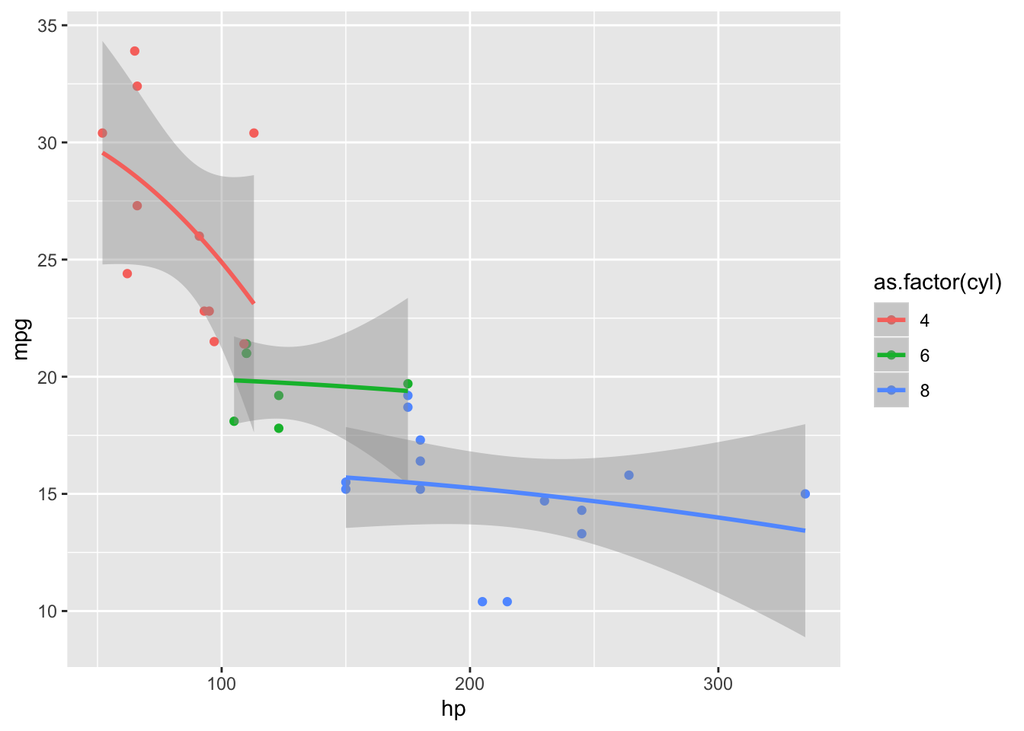

   ```r
   ggplot(mtcars, aes(hp, mpg, color = as.factor(cyl))) +
     geom_point() +
     geom_smooth(method = lm, formula = y ~ I(x^2))
   ```

6. Download the Titanic data set from Moodle and

   Use a bar plot to show how many people survived the Titanic compared to those who didn’t.

   ```r
   titanic <- readr::read_csv("titanic.csv")
   ```

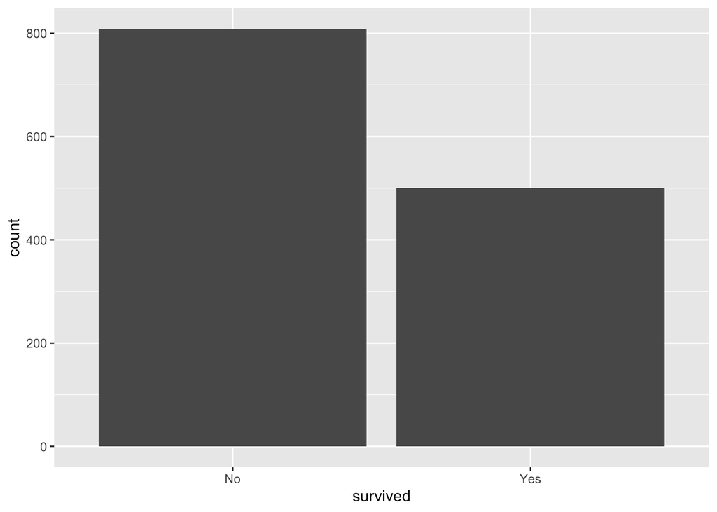

   ```r
   ggplot(titanic, aes(x = survived)) +
     geom_bar()
   ```

   Add a color coding to the previous plot to visualize the differences between the passengers gender.

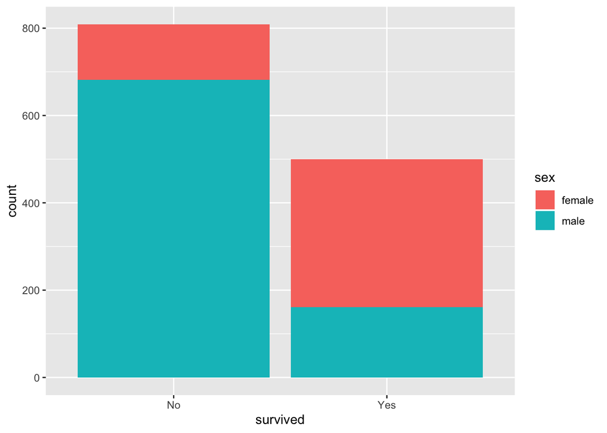

   ```r
   ggplot(titanic, aes(x = survived, fill = sex)) +
     geom_bar()
   ```

   Split the previous plot into three plots based on the passengers class.

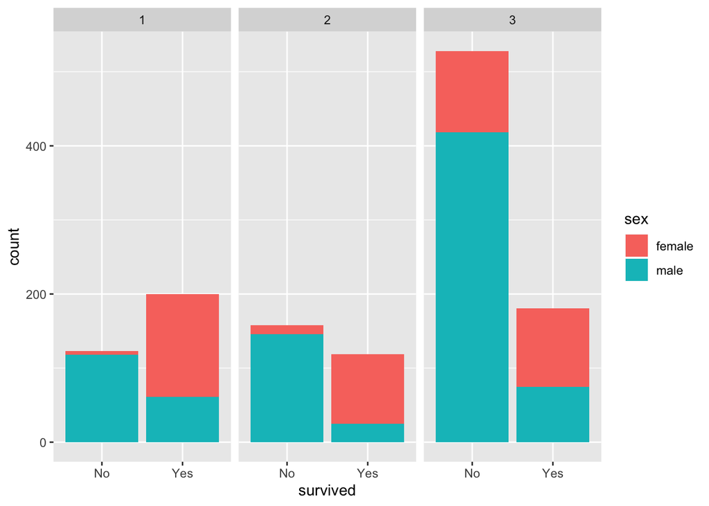

   ```r
   ggplot(titanic, aes(x = survived, fill = sex)) +
     geom_bar() +
     facet_grid(.~pclass)
   ```

   Compare the age distribution between the survivors and non-survivors.

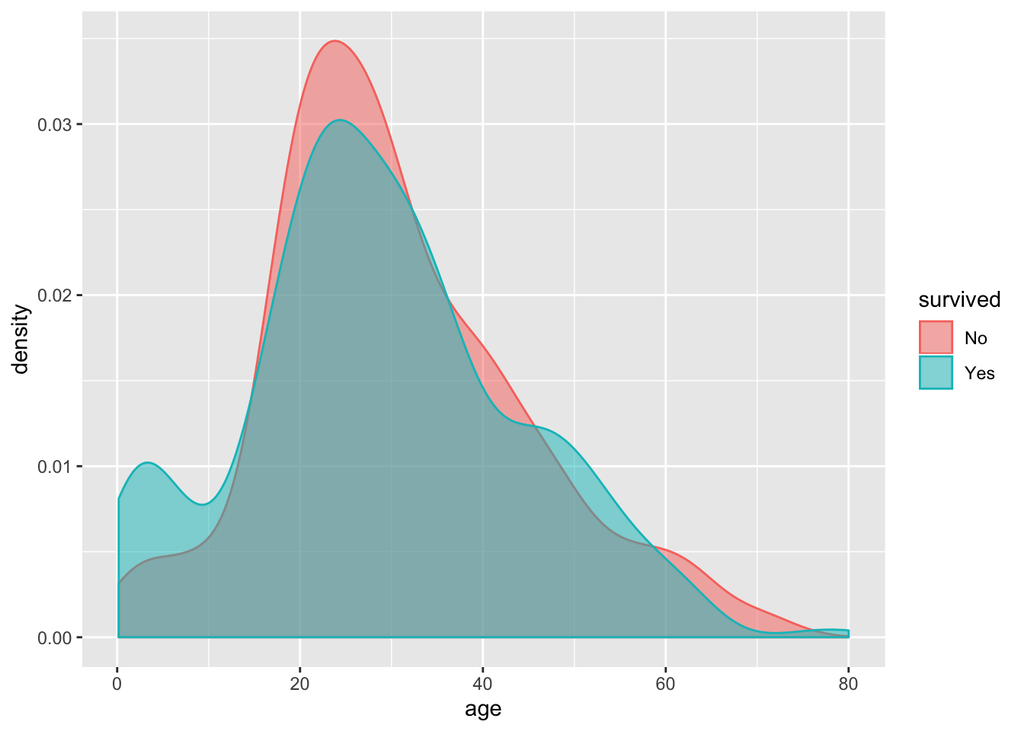

   ```r
   ggplot(titanic, aes(x = age, colour = survived, fill = survived)) +
     geom_density(alpha = 0.5)
   ```

7. Try to answer the following questions about the mpg dataset (comes with ggplot2) using ggplot.